Alexandra Coffin: 2023/2/28: Data Analytics Fundementals: Dr. Case: Project 7, Task 1:

# Chapter 10: Object-Oriented Programming:

### Objectives:

```
* Create custom classes and objects within those classes
* Understand the benefits of crafting valuable classes
* Control access to attributes
* Use Python special methods _repr_, _str_ and _format_ to get an object's string representations.
* Python special methods to overload (redefine operators and utilize them with objects of new classes.
* Iheridence
* Duck Typing
* Understanding class object form which all classes inherit fundemental capabilities
* Building test cases into docstrings and run these tests with doctest
```

## Imports:

```python
from account_def import Account
from decimal import Decimal
import matplotlib.pyplot as plt
import matplotlib.image as mpimg
```

```python
account1 = Account('John Green', Decimal('50.00'))
```

```python
account1.name
```

```
'John Green'
```

```python
account1.balance
```

```
Decimal('50.00')
```

This method will recieve a positive amount and adds it to the balance, of the account.

```python
account1.deposit(Decimal('25.53'))
```

```python
account1.balance
```

```
Decimal('75.53')
```

Class methods validate their arguments, for example if we deposit a nevative deposit, it will raise a ValueError as we written in the imported python file. Base on the fact that it is impossible to deposit a negative amount into an account.

```python
account1.deposit(Decimal('-123.45'))
```

```
---------------------------------------------------------------------------
ValueError                                Traceback (most recent call last)
~\AppData\Local\Temp\ipykernel_3628\2704198404.py in <module>
----> 1 account1.deposit(Decimal('-123.45'))

~\Documents\Data Analytics Sp 2023\Repositories\Reference Repo Sp 2023\datafun-07-ml-predictive\account_def.py in deposit(self, amount)
     26
     27         if amount < Decimal('0.00'):
---> 28             raise ValueError('Amount must be positive.')
     29
     30         self.balance += amount

ValueError: Amount must be positive.
```

## 10.2.2: Account Class Definition:

All classes are broken into different definitions, which int hsi case is located in the custom code accounts_def. This cod dictates the class and the class name, which is found within the class header, which in this case is Line 12. Each class provides a description docstring(Line 6), which when provided must appear in the line or lines immediatly following the class header for readability.

```python
Account?
```

# 10.2.3: Composition: Object References as Memebers of Classes:

Each Account has a name, and a Account has a balance. In order for an object to exist as an object in python, the attributes are refeerences to objects of other classes. In this case an Account object's name attribute is a reference to a string object an an Accounts Object's balance attribute is a reference to a Decimal. In short, by embedding references to objects of other types is known as composition, meaning that there is an established relationship between the attributes of the object and the class it is in.

### Testing the Method to make a Withdraw:

```python
account1 = Account('John Green', Decimal('50.00'))
```

```python
account1.withdraw(Decimal('20.00'))
```

```python
account1.balance
```

```
Decimal('30.00')
```

```python
account1.withdraw(Decimal('100.00'))
```

```
---------------------------------------------------------------------------
ValueError                                Traceback (most recent call last)
~\AppData\Local\Temp\ipykernel_3628\1029263362.py in <module>
----> 1 account1.withdraw(Decimal('100.00'))

~\Documents\Data Analytics Sp 2023\Repositories\Reference Repo Sp 2023\datafun-07-ml-predictive\account_def.py in withdraw(self, amount)
     35         #if amount is greater than balance, raise an exception.
     36         if amount > self.balance:
---> 37             raise ValueError('Amount must be <= to balance.')
     38         elif amount< Decimal('0.00'):
     39             raise ValueError('Amount must be positive.')

ValueError: Amount must be <= to balance.
```

```python
account1.withdraw(Decimal('-10.00'))
```

```
---------------------------------------------------------------------------
ValueError                                Traceback (most recent call last)
~\AppData\Local\Temp\ipykernel_3628\1215017807.py in <module>
----> 1 account1.withdraw(Decimal('-10.00'))

~\Documents\Data Analytics Sp 2023\Repositories\Reference Repo Sp 2023\datafun-07-ml-predictive\account_def.py in withdraw(self, amount)
     37             raise ValueError('Amount must be <= to balance.')
     38         elif amount< Decimal('0.00'):
---> 39             raise ValueError('Amount must be positive.')
     40
     41         self.balance -= amount

ValueError: Amount must be positive.
```

Notice how even though the definition of withdraw has been added to the code, it is possible to get error messages should the logic be ignored. That the amount must be bother positive and less than or equal to the balance, basically unable to withdraw the account.

# 10.3: Controlling Access to Attributes:

Class Account's methods validate their arguments to ensure that the balance is always valid. Attributes name and balance only to get the values of those attributes, but we can also use those attributes to modify their values.

```python
account1 = Account('John Green', Decimal('50.00'))
```

```python
account1.balance
```

```
Decimal('50.00')
```

```python
account1.balance = Decimal('-1000.00')
```

```python
account1.balance
```

```
Decimal('-1000.00')
```

Unlike methods, data attributes cannot validate values assigned to them. A classe's client code allows for the encapsulation of an object's data from the client code. In a sense creating privet data.

# 10.4.1: Test-Driving Class Time

```python
from timewithproperties import Time
```

### Creating a Time Object:

```python
wake_up = Time(hour=6, minute=30)
```

```python
wake_up
```

```
Time(hour=6, minute=30, second=0)
```

```python
print(wake_up)
```

```
6:30:00 AM
```

Class time provides hour, minute and second properties, which provide the convenience of data attributes for getting and modivying an object's data. The properties are implimented as methods, they must contain additional logice, such as specifying the format in which to return the data attribute's value or validating a new value, prior to using it to modify an existing data attribute.

```python
wake_up.hour
```

```
6
```

```python
wake_up.set_time(hour=7, minute=45)
```

```python
wake_up
```

```
Time(hour=7, minute=45, second=0)
```

```python
wake_up.hour = 6
```

```python
wake_up
```

```
Time(hour=6, minute=45, second=0)
```

#### Proving Class Time Validates Values Entered:

```python
wake_up.hour = 100
```

```
---------------------------------------------------------------------------
ValueError                                Traceback (most recent call last)
~\AppData\Local\Temp\ipykernel_3628\238335704.py in <module>
----> 1 wake_up.hour = 100

~\Documents\Data Analytics Sp 2023\Repositories\Reference Repo Sp 2023\datafun-07-ml-predictive\timewithproperties.py in hour(self, hour)
     20         """Set the hour."""
     21         if not (0 <= hour < 24):
---> 22             raise ValueError(f'Hour ({hour}) must be 0-23')
     23
     24         self._hour = hour

ValueError: Hour (100) must be 0-23
```

# 10.4.2: Class Time Definition:

```python
from timewithproperties import Time
```

```python
t = Time()
```

```python
t
```

```
Time(hour=0, minute=0, second=0)
```

```python
t.Time = (12, 30, 45)
```

```python
t
```

```
Time(hour=0, minute=0, second=0)
```

```python
t.Time
```

```
(12, 30, 45)
```

### Creating PrivateData:

```python
from private import PrivateClass
```

```python
my_object = PrivateClass()
```

```python
my_object.public_data
```

```
'public'
```

```python
my_object._private_data
```

```
'private'
```

# 10.6.1: Test Driving Classes Card & DeckOfCards:

```python
from deck import DeckOfCards
```

```python
deck_of_cards = DeckOfCards()
```

```python
print(deck_of_cards)
```

```
Ace of Hearts      2 of Hearts        3 of Hearts        4 of Hearts
5 of Hearts        6 of Hearts        7 of Hearts        8 of Hearts
9 of Hearts        10 of Hearts       Jack of Hearts     Queen of Hearts
King of Hearts     Ace of Diamonds    2 of Diamonds      3 of Diamonds
4 of Diamonds      5 of Diamonds      6 of Diamonds      7 of Diamonds
8 of Diamonds      9 of Diamonds      10 of Diamonds     Jack of Diamonds
Queen of Diamonds  King of Diamonds   Ace of Clubs       2 of Clubs
3 of Clubs         4 of Clubs         5 of Clubs         6 of Clubs
7 of Clubs         8 of Clubs         9 of Clubs         10 of Clubs
Jack of Clubs      Queen of Clubs     King of Clubs      Ace of Spades
2 of Spades        3 of Spades        4 of Spades        5 of Spades
6 of Spades        7 of Spades        8 of Spades        9 of Spades
10 of Spades       Jack of Spades     Queen of Spades    King of Spades
```

We can use the shuffle function to create a shuffled dec of cards.

```python
deck_of_cards.shuffle()
```

```python
print(deck_of_cards)
```

```
3 of Spades        7 of Hearts        Queen of Spades    Queen of Clubs
8 of Diamonds      Ace of Hearts      7 of Diamonds      Jack of Diamonds
3 of Diamonds      10 of Clubs        Jack of Hearts     5 of Clubs
6 of Spades        Ace of Diamonds    6 of Clubs         2 of Clubs
2 of Diamonds      King of Hearts     Queen of Hearts    8 of Spades
9 of Spades        7 of Spades        5 of Diamonds      2 of Hearts
Queen of Diamonds  10 of Diamonds     King of Clubs      6 of Hearts
3 of Hearts        8 of Hearts        Jack of Spades     Ace of Spades
9 of Hearts        8 of Clubs         4 of Spades        5 of Spades
9 of Clubs         4 of Hearts        7 of Clubs         6 of Diamonds
Ace of Clubs       Jack of Clubs      9 of Diamonds      10 of Hearts
10 of Spades       3 of Clubs         2 of Spades        King of Diamonds
4 of Clubs         King of Spades     5 of Hearts        4 of Diamonds
```

### Dealing Cards:

```python
deck_of_cards.deal_card()
```

```
Card(face='3', suit='Spades')
```

```python
card = deck_of_cards.deal_card()
```

```python
str(card)
```

```
'7 of Hearts'
```

```python
card.image_name
```

```
'7_of_Hearts.png'
```

# 10.6.4: Display Card Images with Matplotlib:

```python
from deck import DeckOfCards
```

```python
from pathlib import Path
```

```python
import matplotlib.pyplot as plt
```

```python
import matplotlib.image as mpimg
```

```python
deck_of_cards = DeckOfCards()
```

```python
path = Path('.').joinpath('card_images')
```

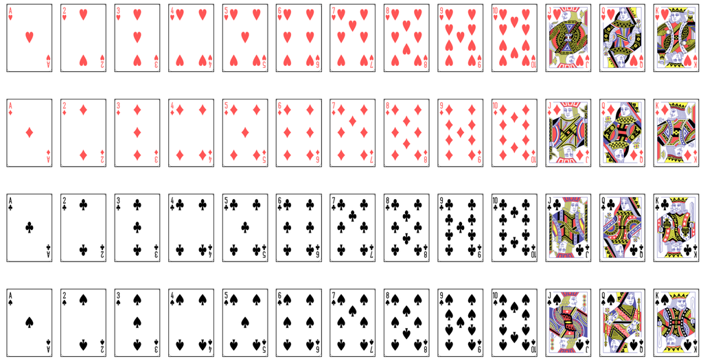

```python
figure, axes_list = plt.subplots(nrows=4, ncols=13)

figure.set_figwidth(16)
figure.set_figheight(9)

for axes in axes_list.ravel():
    axes.get_xaxis().set_visible(False)
    axes.get_yaxis().set_visible(False)
    image_name = deck_of_cards.deal_card().image_name
    img = mpimg.imread(str(path.joinpath(image_name).resolve()))
    axes.imshow(img)

figure.tight_layout()
```

### Shuffle and re-deal the deck

```python
deck_of_cards.shuffle()
```

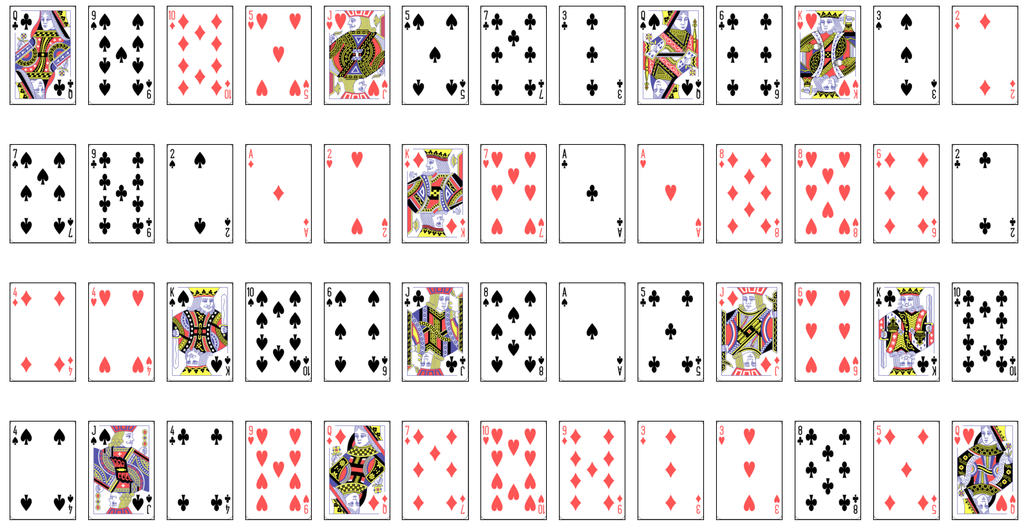

```python
figure, axes_list = plt.subplots(nrows=4, ncols=13)

figure.set_figwidth(16)
figure.set_figheight(9)

for axes in axes_list.ravel():
    axes.get_xaxis().set_visible(False)
    axes.get_yaxis().set_visible(False)
    image_name = deck_of_cards.deal_card().image_name
    img=mpimg.imread(str(path.joinpath(image_name).resolve()))
    axes.imshow(img)

figure.tight_layout()
```

## 10.7.1: ComissionEmployee Base Class

```python
from commissionemployee import CommissionEmployee
```

```python
from decimal import Decimal
```

```python
c = CommissionEmployee('Sue', 'Jones', '333-33-3333',
                     Decimal('10000.00'), Decimal('0.06'))
```

```python
c
```

```
CommissionEmployee: Sue Jones
social security number: 333-33-3333
gross sales: 10000.00
commission rate: 0.06
```

```python
print(f'{c.earnings():,.2f}')
```

```
600.00
```

```python
c.gross_sales = Decimal('20000.00')
```

```python
c.commision_rate = Decimal('0.1')
```

```python
print(f'{c.earnings():,.2f}')
```

```
1,200.00
```

## Testing Class SalariedComissionEmployee

```python
from salariedcommissionemployee import SalariedCommissionEmployee
```

```python
s = SalariedCommissionEmployee('Bob', 'Lewis', '444-44-4444',
                              Decimal('5000.00'), Decimal('0.04'), Decimal('300.00'))
```

```python
print(s.first_name, s.last_name, s.ssn, s.gross_sales,
     s.commission_rate, s.base_salary)
```

```
Bob Lewis 444-44-4444 5000.00 0.04 300.00
```

```python
print(f'{s.earnings():,.2f}')
```

```
500.00
```

```python
s.gross_sales = Decimal('10000.00')
```

```python
s.commision_rate = Decimal('0.05')
```

```python
print(s)
```

```
SalariedCommissionEmployee: Bob Lewis
social security number: 444-44-4444
gross sales: 10000.00
commission rate: 0.04
base salary: 300.00
```

```python
print(f'{s.earnings():,.2f}')
```

[output not shown]

### Testing the "is s" Relationship:

```python
isinstance(s, CommissionEmployee)
```

```
True
```

```python
isinstance(s, SalariedCommissionEmployee)
```

```
True
```

# 10.8.3 Processing Commission & Salaried Employees:

Inheritance allows every object of a subclass to be trated as an object of that subclasse's base class. We can place objects related through inhertitance into a list, then iterate through the list and treat each element as a base-class object. Allowing for objects to be process in a general way/

```python
employees = [c, s]

for employee in employees:
    print(employee)
    print(f'{employee.earnings():,.2f}\n')
```

```
CommissionEmployee: Sue Jones
social security number: 333-33-3333
gross sales: 20000.00
commission rate: 0.06
1,200.00

SalariedCommissionEmployee: Bob Lewis
social security number: 444-44-4444
gross sales: 10000.00
commission rate: 0.04
base salary: 300.00
700.00
```

## 10.9: Duck Typing & Polymorphism:

Duck typing allows for professing an object at execution time, its type doesn't matter, as long as the data attribute, property or method desired is accessable.

```python
class WellPaidDuck:
    def _repr_(self):
        return 'I am a well-paid duck'
    def earnings(self):
        return Decimal('1_000_000.00')
```

```python
from decimal import Decimal
```

```python
from salariedcommissionemployee import SalariedCommissionEmployee
```

```python
c = CommissionEmployee('Sue', 'Jones', '333-33-3333',
                      Decimal('10000.00'), Decimal('0.06'))
```

```python
s = SalariedCommissionEmployee('Bob', 'Lewis', '444-44-4444',
                              Decimal('5000.00'), Decimal('0.04'), Decimal('300.00'))
```

```python
d = WellPaidDuck()
```

```python
employees = [c, s, d]
```

Using the loop from section 10.8.3 to polymorphically process all three objects in the list.

```python
for employee in employees:
    print(employee)
    print(f'{employee.earnings():,.2f}\n')
```

```
CommissionEmployee: Sue Jones
social security number: 333-33-3333
gross sales: 10000.00
commission rate: 0.06
600.00

SalariedCommissionEmployee: Bob Lewis
social security number: 444-44-4444
gross sales: 5000.00
commission rate: 0.04
base salary: 300.00
500.00

<__main__.WellPaidDuck object at 0x00000164558D1610>
1,000,000.00
```

# Chapter 10.10.1: Test-Driving Class Complex:

```python
from complexnumber import Complex
```

```python
x = Complex(real=2, imaginary=4)
```

```python
x
```

```
(2 + 4i)
```

```python
y = Complex(real=5, imaginary=-1)
```

```python
y
```

```
(5 - 1i)
```

```python
x + y
```

```
(7 + 3i)
```

```python
x
```

```
(2 + 4i)
```

```python
y
```

```
(5 - 1i)
```

```python
x += y
```

```python
x
```

```
(7 + 3i)
```

```python
y
```

```
(5 - 1i)
```

# 10.12: Named Tuples:

Collections module also provides named tuples that enable you to refrence a tuple's mebers by name rather than by index number.

```python
from collections import namedtuple
```

```python
card = namedtuple('Card', ['face', 'suit'])
```

```python
card = card(face='Ace', suit='Spades')
```

```python
card.face
```

```
'Ace'
```

```python
card.suit
```

```
'Spades'
```

```python
card
```

```
Card(face='Ace', suit='Spades')
```

## Other Named Tuple Features:

```python
values = ['Queen', 'Hearts']
```

```python
card = card._make(values)
```

```python
card
```

```
Card(face='Queen', suit='Hearts')
```

```python
card._asdict()
```

```
{'face': 'Queen', 'suit': 'Hearts'}
```

## Variable Annotations: Data Attributes:

```python
from dataclasses import dataclass
```

```python
@dataclass
class Demo:
    x #attempting to create a data attribute x
```

```
---------------------------------------------------------------------------
NameError                                 Traceback (most recent call last)
Cell In[15], line 2
      1 @dataclass
----> 2 class Demo:
      3     x #attempting to create a data attribute x

Cell In[15], line 3, in Demo()
      1 @dataclass
      2 class Demo:
----> 3     x

NameError: name 'x' is not defined
```

# 10.13.2: Using the Card Data Class

```python
from carddataclass import Card
```

```python
c1 = Card(Card.FACES[0], Card.SUITS[3])
```

```python
c1
```

```
Card(face='Ace', suit='Spades')
```

```python
c1.face
```

```
'Ace'
```

```python
c1.suit
```

```
'Spades'
```

```python
c1.image_name
```

```
'Ace_of_Spades.png'
```

Demonstrating that Card objects can be compared via the autogenerated == operator and inherited != operator.

```python
c2 = Card(Card.FACES[0], Card.SUITS[3])
```

```python
c2
```

```
Card(face='Ace', suit='Spades')
```

```python
c3 = Card(Card.FACES[0], Card.SUITS[0])
```

```python
c3
```

```
Card(face='Ace', suit='Hearts')
```

```python
c1 == c2
```

```
True
```

```python
c1 == c3
```

```
False
```

```python
c1 != c3
```

```
True
```

```python
from deck2 import DeckOfCards
```

```python
deck_of_cards = DeckOfCards()
print(deck_of_cards)
```

```
Ace of Hearts      2 of Hearts        3 of Hearts        4 of Hearts
5 of Hearts        6 of Hearts        7 of Hearts        8 of Hearts
9 of Hearts        10 of Hearts       Jack of Hearts     Queen of Hearts
King of Hearts     Ace of Diamonds    2 of Diamonds      3 of Diamonds
4 of Diamonds      5 of Diamonds      6 of Diamonds      7 of Diamonds
8 of Diamonds      9 of Diamonds      10 of Diamonds     Jack of Diamonds
Queen of Diamonds  King of Diamonds   Ace of Clubs       2 of Clubs
3 of Clubs         4 of Clubs         5 of Clubs         6 of Clubs
7 of Clubs         8 of Clubs         9 of Clubs         10 of Clubs
Jack of Clubs      Queen of Clubs     King of Clubs      Ace of Spades
2 of Spades        3 of Spades        4 of Spades        5 of Spades
6 of Spades        7 of Spades        8 of Spades        9 of Spades
10 of Spades       Jack of Spades     Queen of Spades    King of Spades
```

# 10.14: Unit Testing with Docstrings and doctest:

We can use the doctest module to help test code and conveniently retest if after you make modifications. The testmod function, inspects your functions', methods' and classes' docstrings looking for sample Python statments proceeded by >>>, each followed on the next line by the given statemetn's expected output.

## Finding Identifiers in Namespaces:

```python
z = 'global z'

def print_variables():
    y = 'local y in print_variables'
    print(y)
    print(z)
```

```python
print_variables()
```

```
local y in print_variables
global z
```

```python
y
```

```
---------------------------------------------------------------------------
NameError                                 Traceback (most recent call last)
Cell In[34], line 1
----> 1 y

NameError: name 'y' is not defined
```

```python
z
```

```
'global z'
```

# Note:

See NoteBook Chpt 10 Examples